# R Notebook

### Assignment May 24

```r
library(tidyverse)
```

[output not shown]

[output cut: 990 more lines]

```r
diamonds %>%
  count(cut)
```

| cut | n |
| --- | --- |
| Fair | 1610 |
| Good | 4906 |
| Very Good | 12082 |
| Premium | 13791 |
| Ideal | 21551 |

```r
diamonds %>%
  count(cut_width(carat, 0.5))
```

| cut_width(carat, 0.5) | n |
| --- | --- |
| [-0.25,0.25] | 785 |
| (0.25,0.75] | 29498 |
| (0.75,1.25] | 15977 |
| (1.25,1.75] | 5313 |
| (1.75,2.25] | 2002 |
| (2.25,2.75] | 322 |
| (2.75,3.25] | 32 |
| (3.25,3.75] | 5 |
| (3.75,4.25] | 4 |
| (4.25,4.75] | 1 |

[output cut: 1 more lines]

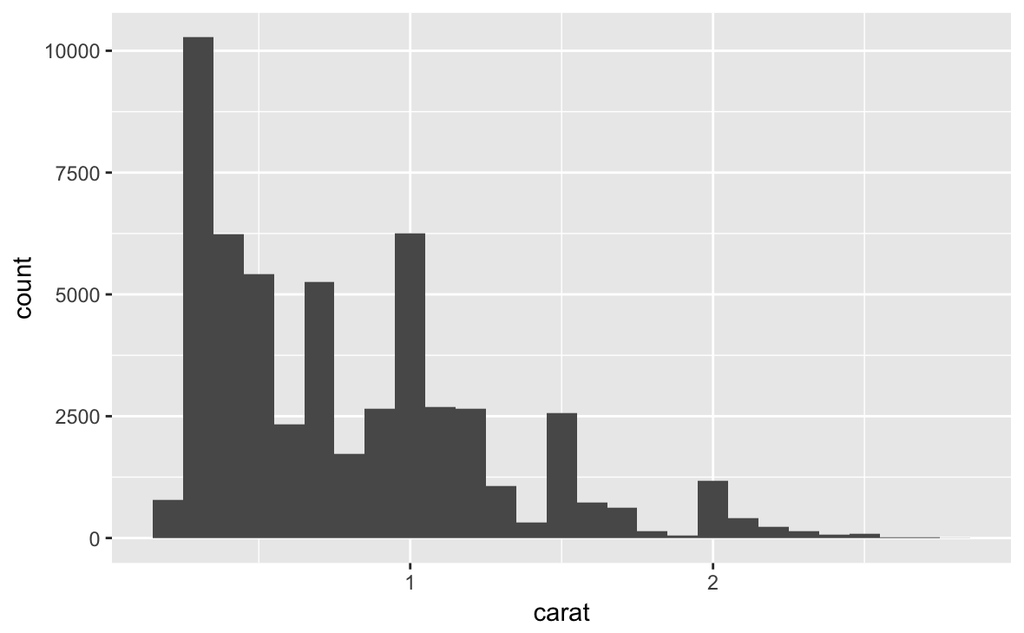

```r
smaller <- diamonds %>%
  filter(carat < 3)

ggplot(data = smaller, mapping = aes(x = carat)) +
  geom_histogram(binwidth = 0.1)
```

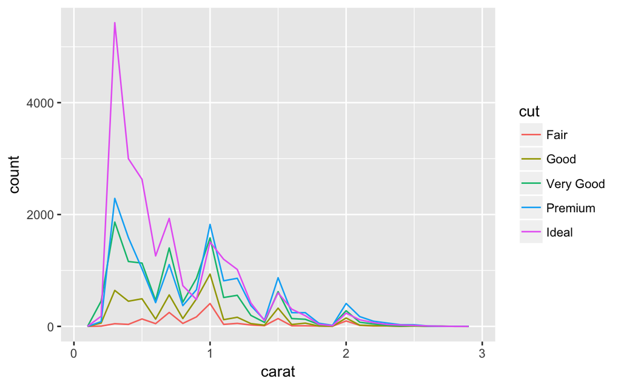

```r
ggplot(data = smaller, mapping = aes(x = carat, colour = cut)) +
  geom_freqpoly(binwidth = 0.1)
```

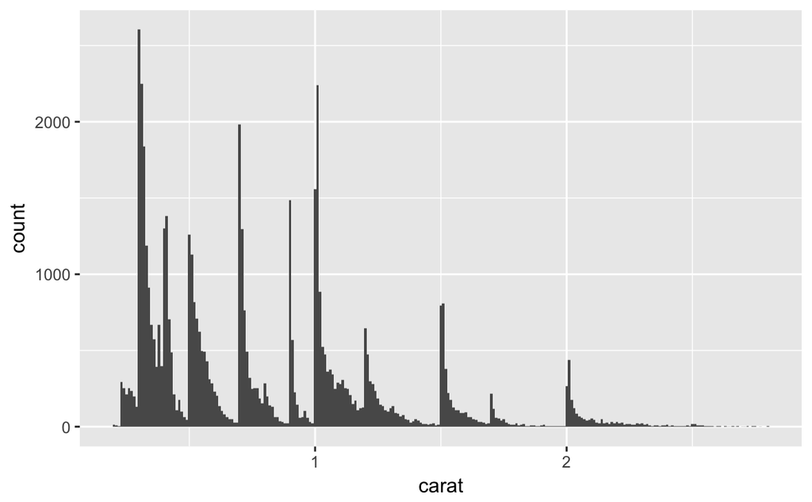

```r
ggplot(data = smaller, mapping = aes(x = carat)) +
  geom_histogram(binwidth = 0.01)
```

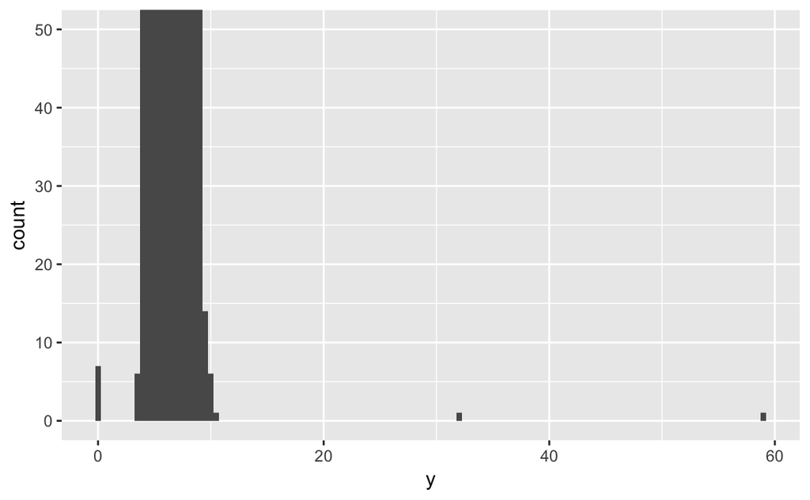

```r
ggplot(diamonds) +
  geom_histogram(mapping = aes(x = y), binwidth = 0.5) +
  coord_cartesian(ylim = c(0, 50))
```

```r
unusual <- diamonds %>%
  filter(y < 3 | y > 20) %>%
  select(price, x, y, z) %>%
  arrange(y)
unusual
```

| price | x | y | z |
| --- | --- | --- | --- |
| 5139 | 0.00 | 0.0 | 0.00 |
| 6381 | 0.00 | 0.0 | 0.00 |
| 12800 | 0.00 | 0.0 | 0.00 |
| 15686 | 0.00 | 0.0 | 0.00 |
| 18034 | 0.00 | 0.0 | 0.00 |
| 2130 | 0.00 | 0.0 | 0.00 |
| 2130 | 0.00 | 0.0 | 0.00 |
| 2075 | 5.15 | 31.8 | 5.12 |
| 12210 | 8.09 | 58.9 | 8.06 |

### Exercise 7.3.4

##### question 1

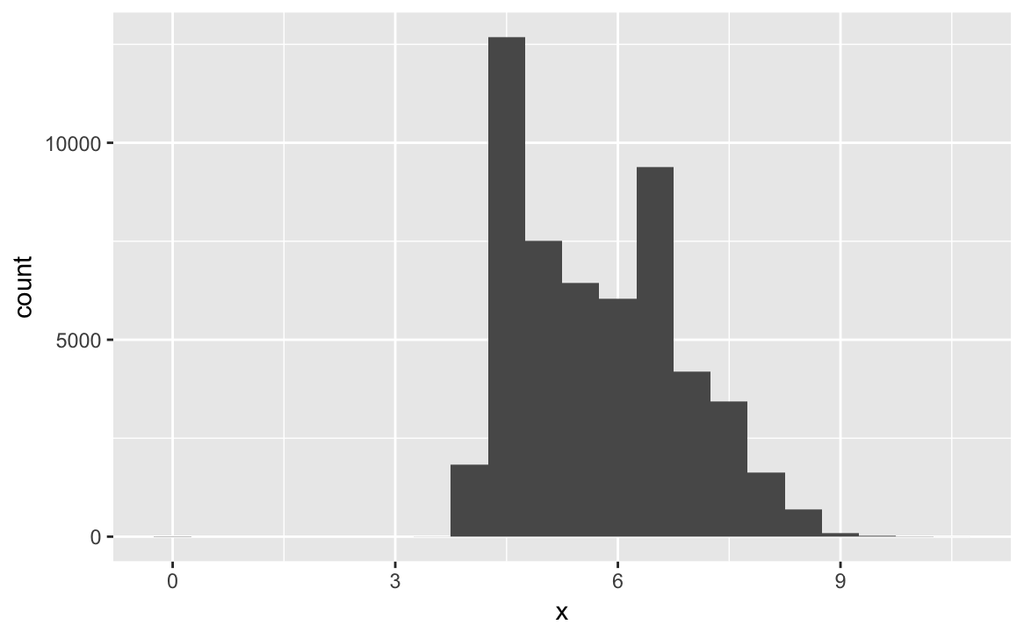

```r
# explore the distribution of x, y, z
ggplot(diamonds) +
  geom_histogram(mapping = aes(x = x), binwidth = 0.5)
```

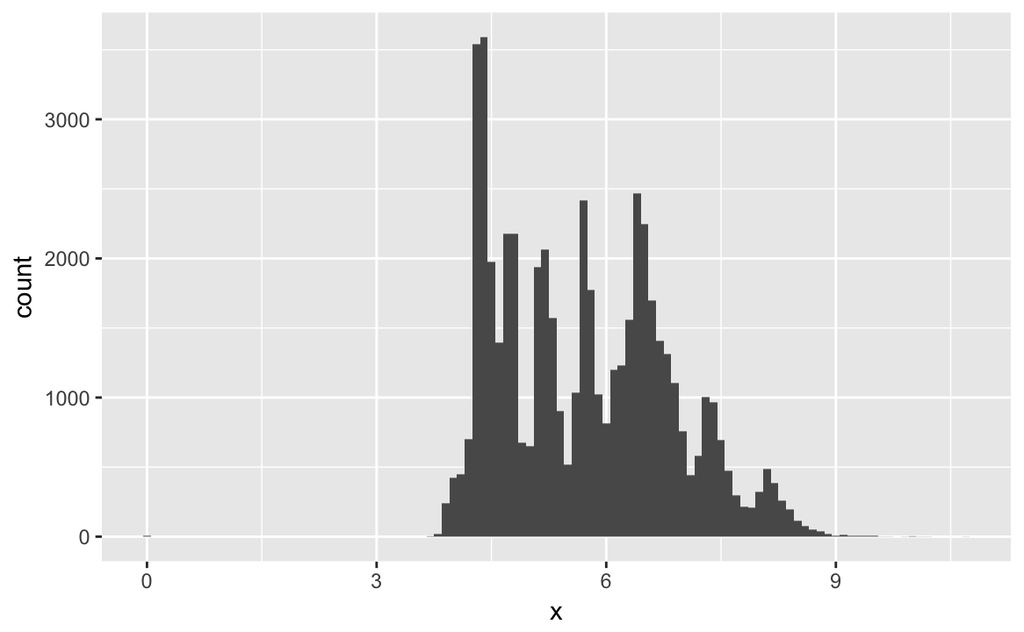

```r
ggplot(diamonds) +
  geom_histogram(mapping = aes(x = x), binwidth = 0.1)
```

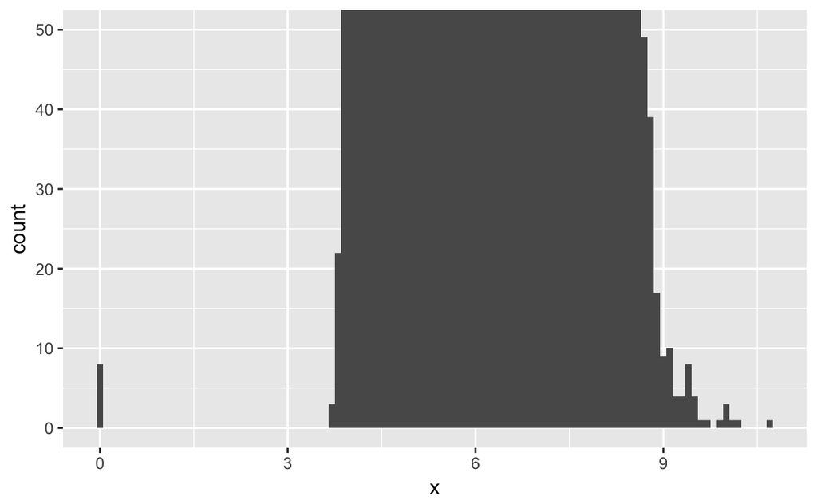

```r
ggplot(diamonds) +
  geom_histogram(mapping = aes(x = x), binwidth = 0.1) +
  coord_cartesian(ylim = c(0, 50))
```

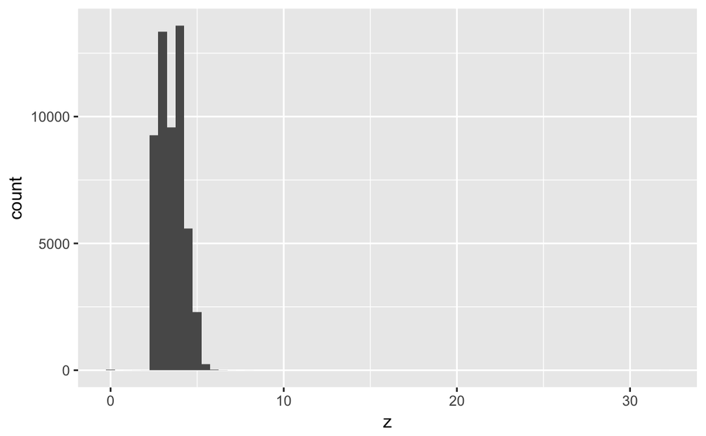

```r
ggplot(diamonds) +
  geom_histogram(mapping = aes(x = z), binwidth = 0.5)
```

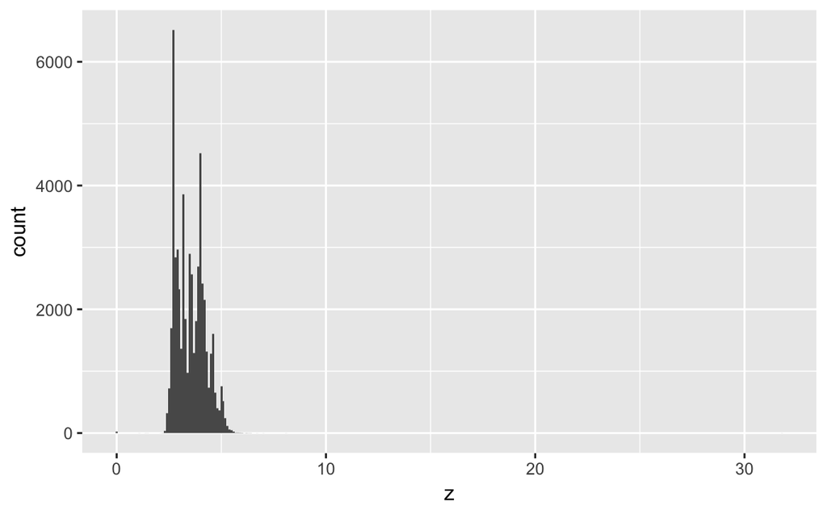

```r
ggplot(diamonds) +
  geom_histogram(mapping = aes(x = z), binwidth = 0.1)
```

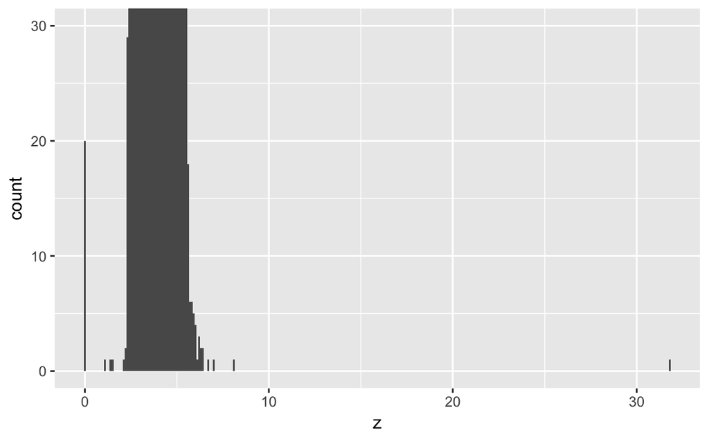

```r
ggplot(diamonds) +
  geom_histogram(mapping = aes(x = z), binwidth = 0.1) +
  coord_cartesian(ylim = c(0, 30))
```

In X, the measurements of length, the distribution falls mostly between 3-9, there are some outliers. For example there are multiple measurements of length 0, which is impossible. The same is true for Z, which is the depth. There are about 20 measurements of 0, which is impossible. As well as a measurement of ~ 31, which is improbable.

##### question 2

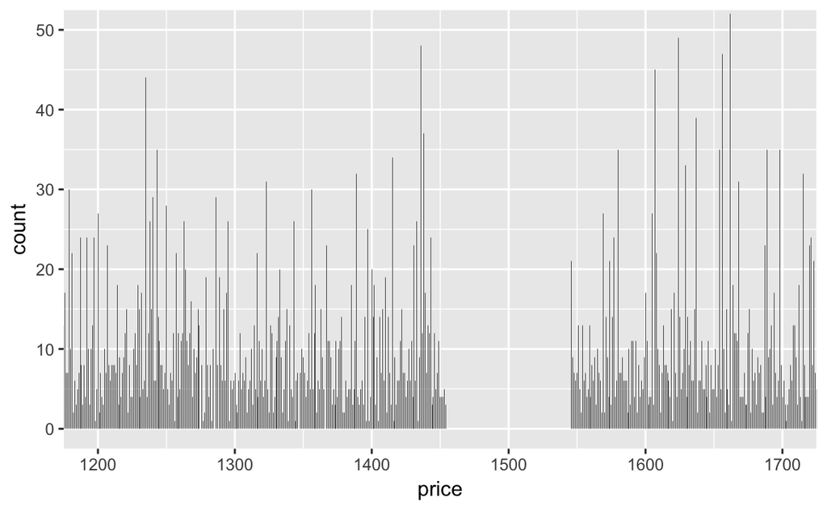

There is an interesting gap of no diamonds costing between ~1450, and ~1550 dollars.

##### question 3

| carat | n |
| --- | --- |
| 1 | 1558 |

##### question 4

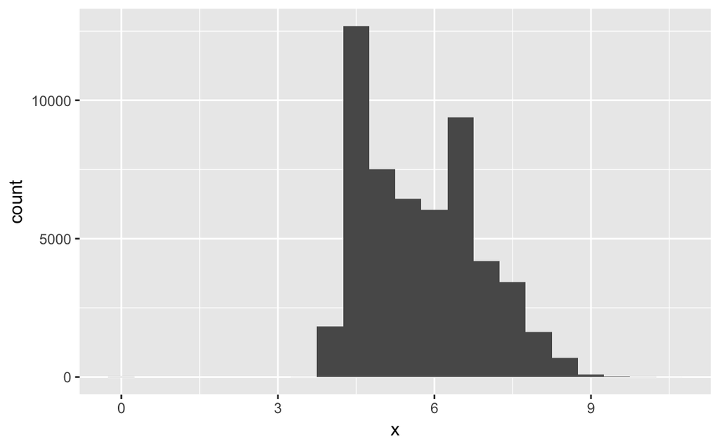

```r
#Compare and contrast coord_cartesian() vs xlim() or ylim() when zooming in on a histogram. What happens if you leave binwidth unset? What happens if you try and zoom so only half a bar shows?
ggplot(diamonds) +
  geom_histogram(mapping = aes(x = x ), binwidth = 0.5)
```

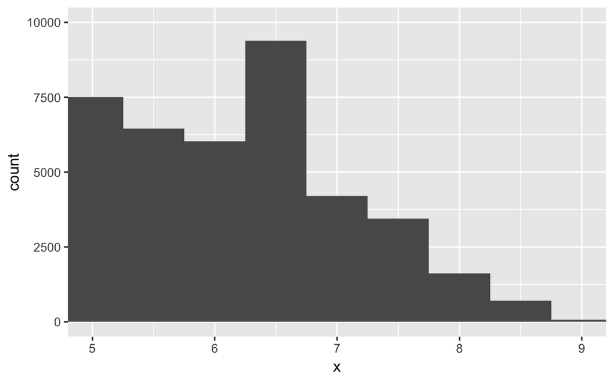

```r
ggplot(diamonds) +
  geom_histogram(mapping = aes(x = x ), binwidth = 0.5) +
  coord_cartesian(xlim = c(5, 9), ylim = c(0,10000))
```

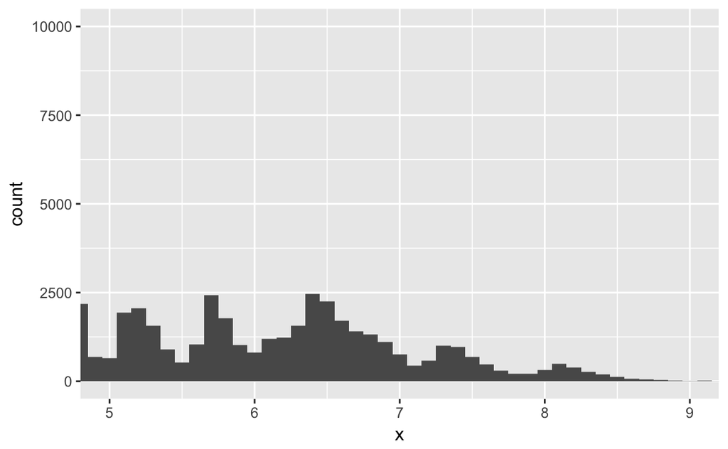

```r
ggplot(diamonds) +
  geom_histogram(mapping = aes(x = x ), binwidth = 0.1) +
  coord_cartesian(xlim = c(5, 9), ylim = c(0,10000))
```

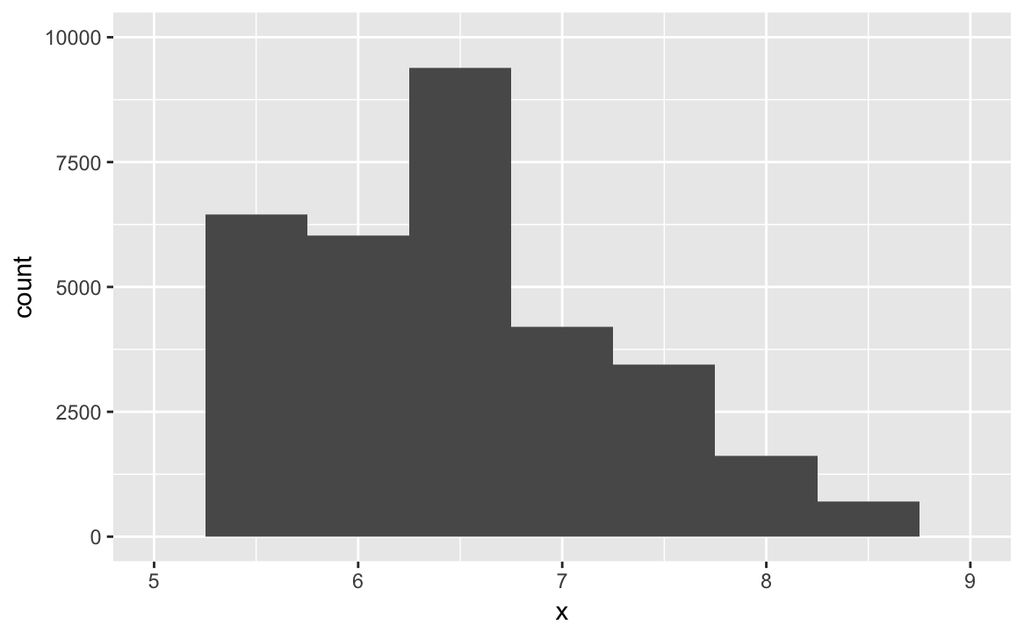

```r
ggplot(diamonds) +
  geom_histogram(mapping = aes(x = x ), binwidth = 0.5) + xlim(5,9) + ylim(0,10000)
```

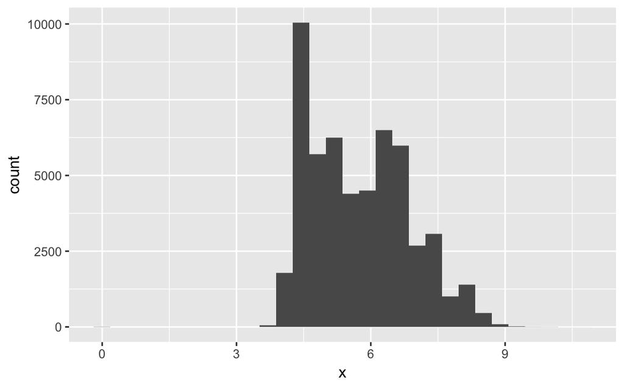

```r
# bindwidth unset
ggplot(diamonds) +
  geom_histogram(mapping = aes(x = x ))
```

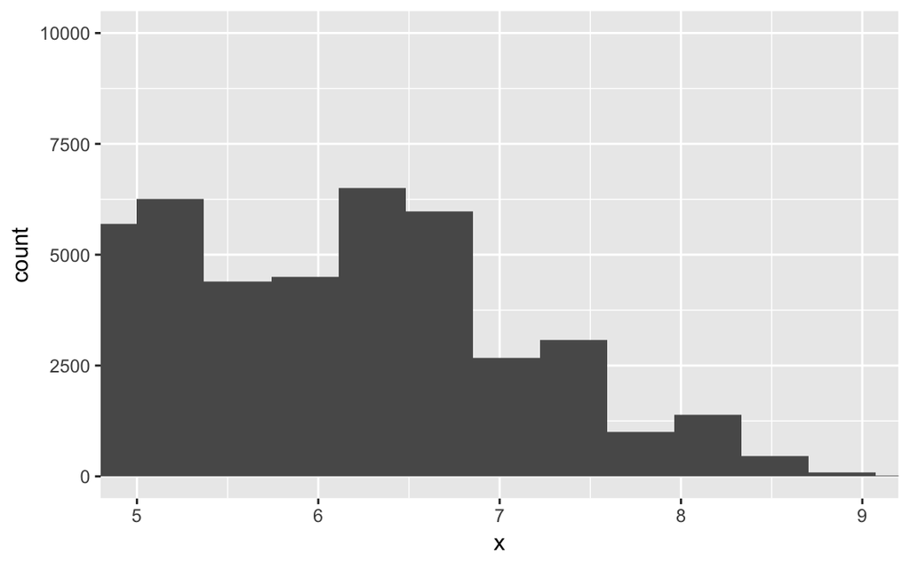

```r
ggplot(diamonds) +
  geom_histogram(mapping = aes(x = x )) +
  coord_cartesian(xlim = c(5, 9), ylim = c(0,10000))
```

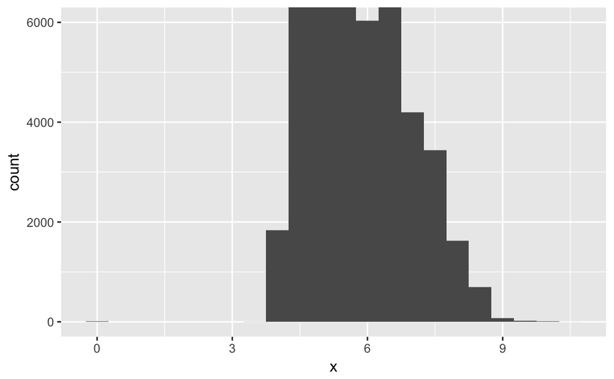

```r
# half way zoom
ggplot(diamonds) +
  geom_histogram(mapping = aes(x = x ), binwidth = 0.5) + coord_cartesian(ylim = c(0,6000))
```

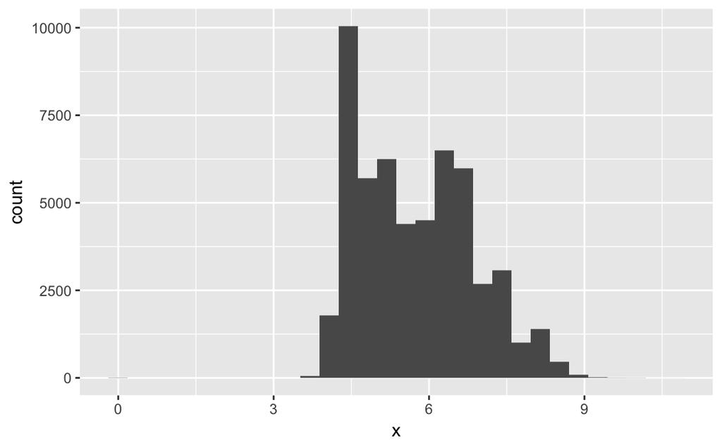

```r
ggplot(diamonds) +
  geom_histogram(mapping = aes(x = x ))
```

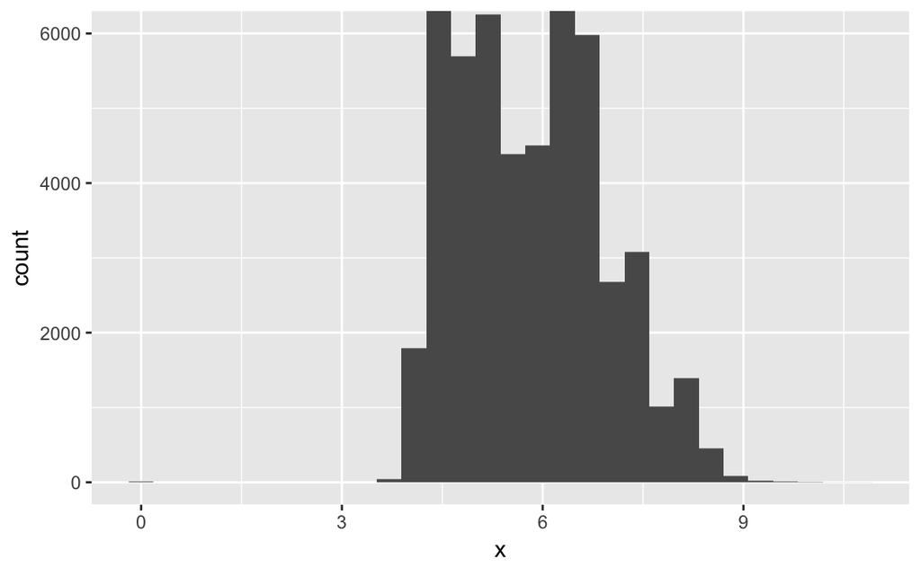

```r
ggplot(diamonds) +
  geom_histogram(mapping = aes(x = x )) + coord_cartesian(ylim = c(0,6000))
```

coord_cartesian zooms in on the numbers chosen. When you use xlim and y lim, it removes the data thats outside of those numbers. When you do not set a binwidth, it uses 30 bins, and the binwidth is set from there.

### Exercise 7.4.1

##### question 1

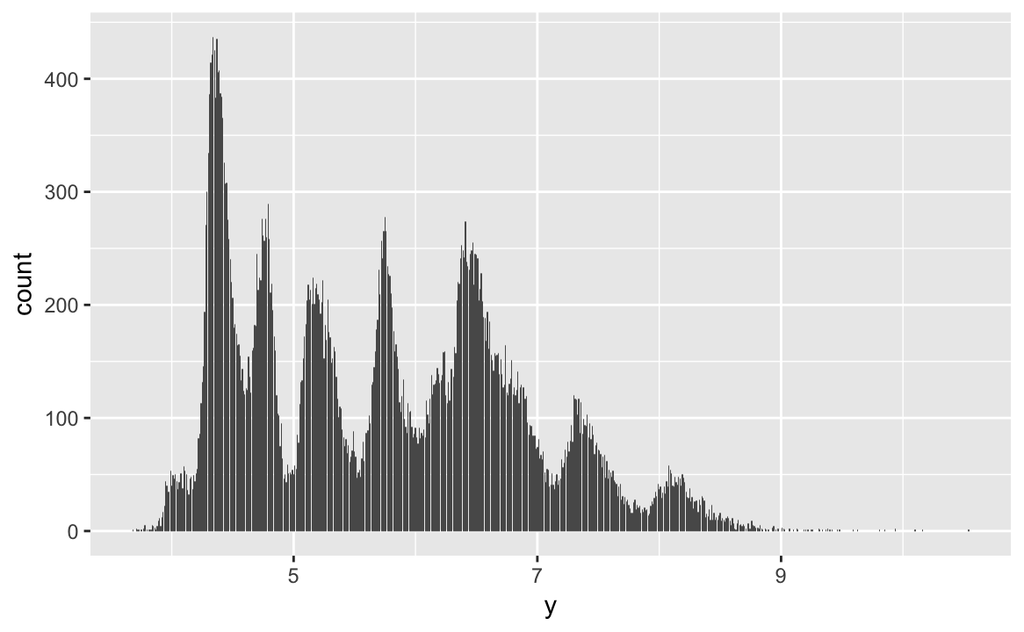

##### Question 2

The na.rm = True is mean, strips the NA values before calculating. In sum, it also decides whether or not to remove the NA before calculating.